신록예찬's 블로그

# (노트) Deploy hynn-iu model

Aug 30, 2021 • 신록예찬 • 7 min read

fastai

- ref
- check jupyter version
- install pkgs
- import
- download data (cat and dog images)
- my first model
- Classifying breeds
- Single-label classification - With the data block API
- Deploy
- test with image crolling
- publish
- Deploy
- publish
- download data (cat and dog images)
- my first model
- 오답분석

### ref

`-` https://ipywidgets.readthedocs.io/en/stable/user_install.html

### check jupyter version

```python
! jupyter --version
```

```
jupyter core     : 4.7.1
jupyter-notebook : 6.4.3
qtconsole        : 5.1.1
ipython          : 7.26.0
ipykernel        : 6.2.0
jupyter client   : 6.1.12
jupyter lab      : 3.1.8
nbconvert        : 5.6.1
ipywidgets       : 7.6.3
nbformat         : 5.1.3
traitlets        : 5.0.5
```

주피터랩 버전이 3.0>0 이상임

### install pkgs

```python
#!pip install graphviz
#!conda install -c conda-forge jupyterlab_widgets -y
#!conda install -c conda-forge ipywidgets -y
#!conda install -c conda-forge nodejs -y
```

### import

```python
from fastai.vision.all import *
from fastai.vision.widgets import *
```

### download data (cat and dog images)

```python
path=untar_data(URLs.PETS)/'images'
```

```python
path
```

```
Path('/home/cgb4/.fastai/data/oxford-iiit-pet/images')
```

```python
path.ls()
```

```
(#7394) [Path('/home/cgb4/.fastai/data/oxford-iiit-pet/images/staffordshire_bull_terrier_106.jpg'),Path('/home/cgb4/.fastai/data/oxford-iiit-pet/images/english_cocker_spaniel_170.jpg'),Path('/home/cgb4/.fastai/data/oxford-iiit-pet/images/leonberger_5.jpg'),Path('/home/cgb4/.fastai/data/oxford-iiit-p…
```

**Note:**

- `URLs.PETS`는 그냥 https://s3.amazonaws.com/fast-ai-imageclas/oxford-iiit-pet.tgz 가 저장된 스트링..

- untar_data()는 fastai에서 제공하는 함수. URL주소를 str으로 받으면 PosixPath Type의 인스턴스를 반환한다.
- PosixPath는 파이썬 자체에서 제공되는 자료형인듯. (이런건 [공식문서](https://docs.python.org/ko/3/library/pathlib.html)가 잘 정리되어있다.)
- PosixPath 타입은 `/` operator를 통해 문자열과 결합할 수 있음.
- PosixPath 타입은 ls method를 통하여 path에 저장된 파일들의 목록을 출력할 수 있음

```python
files = get_image_files(path)
files
```

```
(#7390) [Path('/home/cgb4/.fastai/data/oxford-iiit-pet/images/staffordshire_bull_terrier_106.jpg'),Path('/home/cgb4/.fastai/data/oxford-iiit-pet/images/english_cocker_spaniel_170.jpg'),Path('/home/cgb4/.fastai/data/oxford-iiit-pet/images/leonberger_5.jpg'),Path('/home/cgb4/.fastai/data/oxford-iiit-p…
```

```python
files[0],files[1],files[2],files[3],files[4]
```

```
(Path('/home/cgb4/.fastai/data/oxford-iiit-pet/images/staffordshire_bull_terrier_106.jpg'),
 Path('/home/cgb4/.fastai/data/oxford-iiit-pet/images/english_cocker_spaniel_170.jpg'),
 Path('/home/cgb4/.fastai/data/oxford-iiit-pet/images/leonberger_5.jpg'),
 Path('/home/cgb4/.fastai/data/oxford-iiit-pet/images/shiba_inu_209.jpg'),
 Path('/home/cgb4/.fastai/data/oxford-iiit-pet/images/american_pit_bull_terrier_104.jpg'))
```

```python
def label_func(f):
    if f[0].isupper():
        return 'cat'
    else:
        return 'dog'
```

```python
label_func('asdf')
```

```
'dog'
```

```python
dls = ImageDataLoaders.from_name_func(path, files, label_func, item_tfms=Resize(224)) ## 데이터로더는 좀더 탐구필요
# dls = ImageDataLoaders.from_name_func(
#     path, get_image_files(path),valid_pct=0.2, seed=42,
#     label_func=is_cat, item_tfms=Resize(224))
```

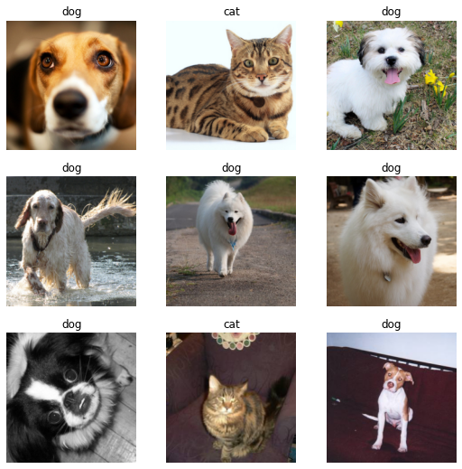

```python
dls.show_batch(max_n=9) # 실행할때마다 결과바뀜
```

### my first model

```python
learn=cnn_learner(dls,resnet34, metrics=error_rate)
```

```python
learn.fine_tune(1)
```

| epoch | train_loss | valid_loss | error_rate | time |
| --- | --- | --- | --- | --- |
| 0 | 0.151400 | 0.018712 | 0.004736 | 00:09 |

| epoch | train_loss | valid_loss | error_rate | time |
| --- | --- | --- | --- | --- |
| 0 | 0.068201 | 0.004507 | 0.002030 | 00:11 |

**Note:** CPU vs GPU 하면 좋을듯

```python
learn.predict(files[0])
```

```
('dog', tensor(1), tensor([2.1661e-06, 1.0000e+00]))
```

**Note:** 그림파일이 저장된 경로를 PosixPath타입으로 전달하면 예측결과가 출력됨

```python
learn.predict([files[0],files[1]])
```

[output not shown]

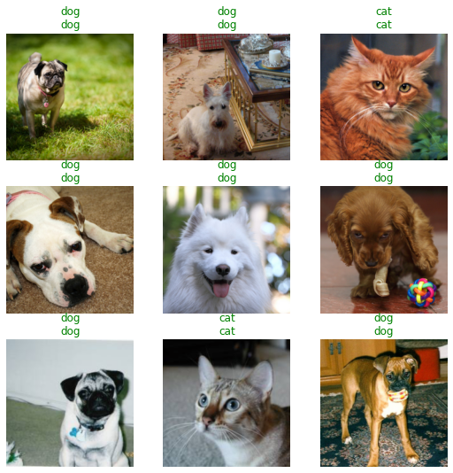

```python
learn.show_results()
```

### Classifying breeds

```python
files[0].name
```

```
'staffordshire_bull_terrier_106.jpg'
```

```python
pat=r'^(.*)_\d+.jpg'
```

```python
pat
```

```
'^(.*)_\\d+.jpg'
```

```python
dls2 = ImageDataLoaders.from_name_re(path, files, pat, item_tfms=Resize(224))
```

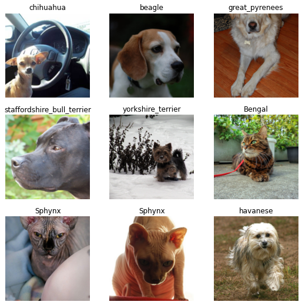

```python
dls2.show_batch()
```

```python
learn2 = cnn_learner(dls2, resnet34, metrics=error_rate)
```

```
SuggestedLRs(minimum=0.00831763744354248, steep=0.0030199517495930195, valley=0.0004786300996784121, slide=1.2022644114040304e-05)
```

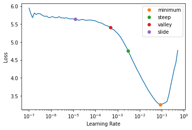

```python
learn2.lr_find(suggest_funcs=(minimum, steep, valley, slide)) ##??
```

```python
learn2.fine_tune(10)
```

| epoch | train_loss | valid_loss | error_rate | time |
| --- | --- | --- | --- | --- |
| 0 | 0.266045 | 0.280622 | 0.085927 | 00:09 |

| epoch | train_loss | valid_loss | error_rate | time |
| --- | --- | --- | --- | --- |
| 0 | 0.186178 | 0.246577 | 0.075101 | 00:11 |
| 1 | 0.155443 | 0.328487 | 0.094723 | 00:11 |
| 2 | 0.186107 | 0.383623 | 0.102165 | 00:11 |
| 3 | 0.147189 | 0.320890 | 0.082544 | 00:11 |
| 4 | 0.102873 | 0.461999 | 0.107578 | 00:11 |
| 5 | 0.081483 | 0.278026 | 0.064276 | 00:11 |
| 6 | 0.039981 | 0.272739 | 0.073748 | 00:11 |
| 7 | 0.026106 | 0.254507 | 0.064276 | 00:11 |
| 8 | 0.019918 | 0.249692 | 0.063599 | 00:11 |
| 9 | 0.015702 | 0.241561 | 0.060893 | 00:11 |

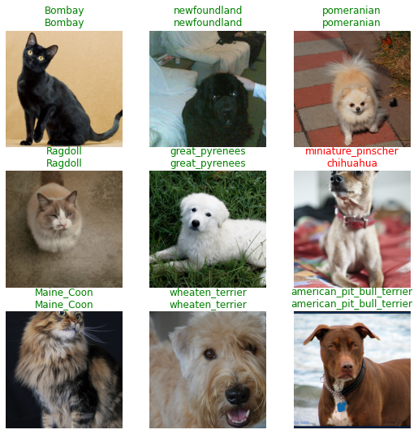

```python
learn2.show_results()
```

```python
learn2.fine_tune(10,0.0002)
```

| epoch | train_loss | valid_loss | error_rate | time |
| --- | --- | --- | --- | --- |
| 0 | 0.009879 | 0.243595 | 0.061570 | 00:09 |

| epoch | train_loss | valid_loss | error_rate | time |
| --- | --- | --- | --- | --- |
| 0 | 0.010000 | 0.254422 | 0.062246 | 00:11 |
| 1 | 0.009001 | 0.244022 | 0.059540 | 00:11 |
| 2 | 0.007601 | 0.240727 | 0.058863 | 00:11 |
| 3 | 0.007846 | 0.249908 | 0.062246 | 00:11 |
| 4 | 0.006549 | 0.245065 | 0.060217 | 00:11 |
| 5 | 0.006561 | 0.238890 | 0.061570 | 00:11 |
| 6 | 0.004877 | 0.240195 | 0.056157 | 00:11 |
| 7 | 0.005985 | 0.237253 | 0.059540 | 00:11 |
| 8 | 0.005878 | 0.241390 | 0.058863 | 00:11 |
| 9 | 0.003562 | 0.238951 | 0.058187 | 00:11 |

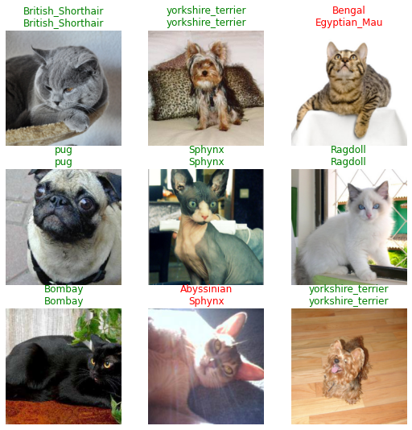

```python
learn2.show_results()
```

```python
interp2 = Interpretation.from_learner(learn2)
```

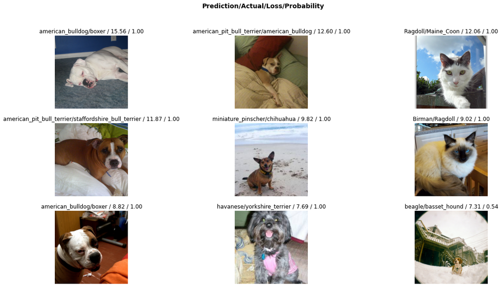

```python
interp2.plot_top_losses(9,figsize=(20,10))
```

### Single-label classification - With the data block API

### Deploy

```python
import ipywidgets as widgets
uploader=widgets.FileUpload()
display(uploader)
```

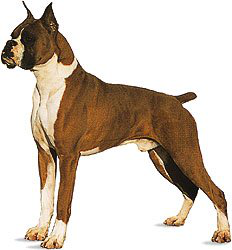

```python
img=PILImage.create(uploader.data[0])
img
```

```python
is_cat,_,probs = learn.predict(img)
```

```python
is_cat
```

```
'False'
```

```python
probs
```

```
tensor([0.9698, 0.0302])
```

### test with image crolling

```python
def search_images_ddg(key,max_n=200):
    """Search for 'key' with DuckDuckGo and return a unique urls of 'max_n' images
       (Adopted from https://github.com/deepanprabhu/duckduckgo-images-api)
    """
    url        = 'https://duckduckgo.com/'
    params     = {'q':key}
    res        = requests.post(url,data=params)
    searchObj  = re.search(r'vqd=([\d-]+)\&',res.text)
    if not searchObj: print('Token Parsing Failed !'); return
    requestUrl = url + 'i.js'
    headers    = {'User-Agent': 'Mozilla/5.0 (X11; Ubuntu; Linux x86_64; rv:71.0) Gecko/20100101 Firefox/71.0'}
    params     = (('l','us-en'),('o','json'),('q',key),('vqd',searchObj.group(1)),('f',',,,'),('p','1'),('v7exp','a'))
    urls       = []
    while True:
        try:
            res  = requests.get(requestUrl,headers=headers,params=params)
            data = json.loads(res.text)
            for obj in data['results']:
                urls.append(obj['image'])
                max_n = max_n - 1
                if max_n < 1: return L(set(urls))     # dedupe
            if 'next' not in data: return L(set(urls))
            requestUrl = url + data['next']
        except:
            pass
```

`-` https://github.com/fastai/fastbook/blob/master/utils.py

```python
urls = search_images_ddg('강아지', max_n=10)
len(urls),urls[0]
```

```
(10,
 'https://www.saemo.com/data/file/channel/thumb-2728265535_nezlJroF_50b689cf3c8ccdfbdc58d3e47be71778f24c3b48_600x800.jpg')
```

```python
def download_url(url, dest, overwrite=False, pbar=None, show_progress=True, chunk_size=1024*1024,
                 timeout=4, retries=5):
    "Download `url` to `dest` unless it exists and not `overwrite`"
    if os.path.exists(dest) and not overwrite: return

    s = requests.Session()
    s.mount('http://',requests.adapters.HTTPAdapter(max_retries=retries))
    # additional line to identify as a firefox browser, see fastai/#2438
    s.headers.update({'User-Agent': 'Mozilla/5.0 (X11; Ubuntu; Linux x86_64; rv:71.0) Gecko/20100101 Firefox/71.0'})
    u = s.get(url, stream=True, timeout=timeout)
    try: file_size = int(u.headers["Content-Length"])
    except: show_progress = False

    with open(dest, 'wb') as f:
        nbytes = 0
        if show_progress: pbar = progress_bar(range(file_size), leave=False, parent=pbar)
        try:
            if show_progress: pbar.update(0)
            for chunk in u.iter_content(chunk_size=chunk_size):
                nbytes += len(chunk)
                if show_progress: pbar.update(nbytes)
                f.write(chunk)
        except requests.exceptions.ConnectionError as e:
            fname = url.split('/')[-1]
            data_dir = dest.parent
            print(f'\n Download of {url} has failed after {retries} retries\n'
                  f' Fix the download manually:\n'
                  f'$ mkdir -p {data_dir}\n'
                  f'$ cd {data_dir}\n'
                  f'$ wget -c {url}\n'
                  f'$ tar xf {fname}\n'
                  f' And re-run your code once the download is successful\n')
```

`-` ref: https://github.com/fastai/fastai2/blob/master/fastai2/data/external.py

```python
imgs=[]
for i in range(len(urls)):
    download_url(urls[i],'temp.jpg')
    imgs=imgs+[Image.open('temp.jpg')]
    imgs[i].thumbnail((256,256))
```

```python
a=Image.open('temp.jpg')
```

```python
imgs
```

```
[<PIL.JpegImagePlugin.JpegImageFile image mode=RGB size=192x256 at 0x7F35EE056AF0>,
 <PIL.JpegImagePlugin.JpegImageFile image mode=RGB size=192x256 at 0x7F35EE056820>,
 <PIL.JpegImagePlugin.JpegImageFile image mode=RGB size=192x256 at 0x7F35EE056730>,
 <PIL.JpegImagePlugin.JpegImageFile image mode=RGB size=192x256 at 0x7F35EE056AC0>,
 <PIL.JpegImagePlugin.JpegImageFile image mode=RGB size=192x256 at 0x7F35EE056C10>,
 <PIL.JpegImagePlugin.JpegImageFile image mode=RGB size=192x256 at 0x7F35EE056790>,
 <PIL.JpegImagePlugin.JpegImageFile image mode=RGB size=192x256 at 0x7F35795B6A00>,
 <PIL.JpegImagePlugin.JpegImageFile image mode=RGB size=192x256 at 0x7F35EE056FA0>,
 <PIL.JpegImagePlugin.JpegImageFile image mode=RGB size=192x256 at 0x7F35EE071130>,
 <PIL.JpegImagePlugin.JpegImageFile image mode=RGB size=192x256 at 0x7F35EE071070>]
```

```python
uploader=widgets.FileUpload()
display(uploader)
```

```python
img=PILImage.create(uploader.data[0])
is_cat,_,probs = learn.predict(img)
```

```
---------------------------------------------------------------------------
IndexError                                Traceback (most recent call last)
/tmp/ipykernel_42196/3910415691.py in <module>
----> 1 img=PILImage.create(uploader.data[0])
      2 is_cat,_,probs = learn.predict(img)

IndexError: list index out of range
```

```python
is_cat
```

```
'False'
```

```python
probs
```

```
tensor([9.9991e-01, 8.9673e-05])
```

### publish

```python
btn_upload = widgets.FileUpload()
btn_upload
```

```python
out_pl=widgets.Output()
# out_pl.clear_output()
# with out_pl: display(img.to_thumb(128,128))
# out_pl
```

```python
lbl_pred=widgets.Label()
```

```python
lbl_pred
```

```python
btn_run=widgets.Button(description='Classify')
btn_run
```

```python
def on_click_classify(change):
    img=PILImage.create(btn_upload.data[-1])
    out_pl.clear_output()
    with out_pl: display(img.to_thumb(128,128))
    pred,pred_idx,probs=learn.predict(img)
    lbl_pred.value=f'Prediction:{pred};Probability:{probs[pred_idx]:}'
btn_run.on_click(on_click_classify)
```

```python
VBox([widgets.Label('Select your bear!'),
      btn_upload, btn_run, out_pl, lbl_pred])
```

### Deploy

```python
uploader=widgets.FileUpload()
display(uploader)
```

```python
img=PILImage.create(uploader.data[0])
img
```

```python
pred,_,probs = learn.predict(img)
```

```python
pred,probs
```

### publish

```python
btn_upload = widgets.FileUpload()
btn_upload
```

```python
out_pl=widgets.Output()
# out_pl.clear_output()
# with out_pl: display(img.to_thumb(128,128))
# out_pl
```

```python
lbl_pred=widgets.Label()
```

```python
lbl_pred
```

```python
btn_run=widgets.Button(description='Classify')
btn_run
```

```python
def on_click_classify(change):
    img=PILImage.create(btn_upload.data[-1])
    out_pl.clear_output()
    with out_pl: display(img.to_thumb(128,128))
    pred,pred_idx,probs=learn.predict(img)
    lbl_pred.value=f'Prediction:{pred};Probability:{probs[pred_idx]:}'
btn_run.on_click(on_click_classify)
```

```python
VBox([widgets.Label('Select your bear!'),
      btn_upload, btn_run, out_pl, lbl_pred])
```

### download data (cat and dog images)

```python
path=untar_data(URLs.PETS)/'images'
```

```python
path
```

```python
path.ls()
```

```python
files = get_image_files(path)
files
```

```python
files[0],files[1],files[2],files[3],files[4]
```

```python
def label_func(f):
    if f[0].isupper():
        return 'cat'
    else:
        return 'dog'
```

```python
label_func('asdf')
```

```python
dls = ImageDataLoaders.from_name_func(path, files, label_func, item_tfms=Resize(224)) ## 데이터로더는 좀더 탐구필요
# dls = ImageDataLoaders.from_name_func(
#     path, get_image_files(path),valid_pct=0.2, seed=42,
#     label_func=is_cat, item_tfms=Resize(224))
```

```python
dls.show_batch(max_n=9) # 실행할때마다 결과바뀜
```

### my first model

```python
learn=cnn_learner(dls,resnet34, metrics=error_rate)
```

```python
learn.fine_tune(1)
```

> CPU vs GPU 하면 좋을듯

```python
learn.predict(files[0])
```

**Note:** 그림파일이 저장된 경로를 PosixPath타입으로 전달하면 예측결과가 출력됨

```python
learn.show_results()
```

### 오답분석

```python
interp = Interpretation.from_learner(learn)
```

```python
interp.plot_top_losses(16)
```